# Non-parametric survival methods in R: single group

Shannon Pileggi

February 9, 2018

# Getting started

1. Install the `survival` package. This can be done through `Packages` -> `Install` or with

```r
install.packages("survival")
```

This should only need to be done once on your personal computer; you may or may not need to do this for each session on the library computers.

2. Load the `survival` package.

```r
library(survival)
```

# Basic survival

## Create a survival object

A survival object consists of two vectors:

- time to event
- censoring status

For example, suppose we have the following 7 motorist reaction times:

`1.41 1.41+ 2.76+ 3.56 4.18 4.71+ 13.18`

From this, we can construct a vector of times and a vector with the censoring status (1 = complete, 0 = right-censored). In this case, I will create the vectors in a data frame.

**Note:** You do **not** need to do this `data.frame` step if you have imported the data as a data frame with a command like `read.csv` or `read.table`. This was only used to construct a data set from “raw” data.

```r
motorists <- data.frame(time = c(1.41, 1.41, 2.76, 3.56, 4.18, 4.71, 13.18),
                        censor = c(1, 0, 0, 1, 1, 0, 1))
motorists
```

```
##    time censor
## 1  1.41      1
## 2  1.41      0
## 3  2.76      0
## 4  3.56      1
## 5  4.18      1
## 6  4.71      0
## 7 13.18      1
```

A survival object uses the `Surv` function to combine the `time` and `censor` vectors.

```r
motorists_surv <- Surv(motorists$time, motorists$censor)
```

## Obtain Kaplan-Meier estimates

Use the `survfit` function on your survival object to obtain Kaplan-Meier estimates. Here, we are using modeling syntax where `~ 1` represents that we are creating an intercept only model.

```r
KM_obj <- survfit(motorists_surv ~ 1,
                  conf.type = "none")
```

Then produce a summary of your Kaplan-Meier object with the `summary` function.

```r
summary(KM_obj)
```

```
## Call: survfit(formula = motorists_surv ~ 1, conf.type = "none")
##
##   time n.risk n.event survival std.err
##   1.41      7       1    0.857   0.132
##   3.56      4       1    0.643   0.210
##   4.18      3       1    0.429   0.224
##  13.18      1       1    0.000     NaN
```

You can also get additional information from your Kaplan-Meier object just by submitting the name of the object - this give the sample size, the number of events, and the estimated median survival time.

```r
KM_obj
```

```
## Call: survfit(formula = motorists_surv ~ 1, conf.type = "none")
##
##      n events median
##   7.00   4.00   4.18
```

## Create a survival object when you obtain KM estimates

You don’t have to first specify the survival object and then use `survfit` - this can be done in one step as:

```r
KM_obj <- survfit(Surv(time, censor) ~ 1,
                  data = motorists,
                  conf.type = "none")

summary(KM_obj)
```

```
## Call: survfit(formula = Surv(time, censor) ~ 1, data = motorists, conf.type = "none")
##
##   time n.risk n.event survival std.err
##   1.41      7       1    0.857   0.132
##   3.56      4       1    0.643   0.210
##   4.18      3       1    0.429   0.224
##  13.18      1       1    0.000     NaN
```

## Plotting

### base R

To plot the Kaplan-Meier curve, just execute the `plot` function on the `KM_obj`.

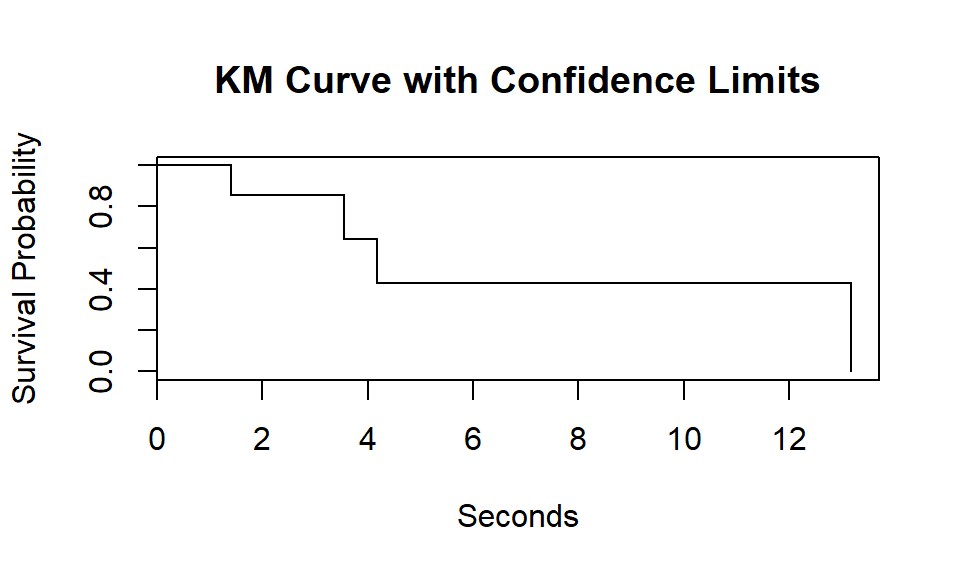

```r
plot(KM_obj,
     xlab = "Seconds",
     ylab = "Survival Probability",
     main = "KM Curve with Confidence Limits")
```

### ggsurvplot

To use a `gg` version of survival plotting, install the `survminer` package and use the `ggsurvplot` function. Note that this function has many options, including whether or not to plot confidence intervals (`conf.int`) or the risk table (`risk.table`). Note that I received an error in `ggsurvplot` when I had `conf.type = "none"` in my `KM_obj`, but when I set `conf.type = "plain"` I no longer received an error.

```r
library(survminer)
```

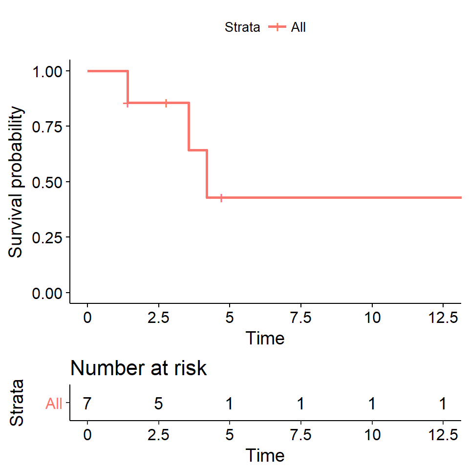

```r
KM_obj <- survfit(Surv(time, censor) ~ 1,
                  data = motorists,
                  conf.type = "plain")

ggsurvplot(KM_obj, data = motorists, conf.int = FALSE, risk.table = TRUE)
```

## Confidence limits

For `conf.type`:

- `none` omits confidence intervals
- `plain` computes standard confidence intervals
- `log-log` computes confidence intervals based on the log-log transformation

Plotting a Kaplan-Meier object that specified confidence limits will automatically plot the confidence limits.

```r
KM_obj <- survfit(Surv(time, censor) ~ 1,
                  data = motorists,
                  conf.type = "plain")

summary(KM_obj)
```

```
## Call: survfit(formula = Surv(time, censor) ~ 1, data = motorists, conf.type = "plain")
##
##   time n.risk n.event survival std.err lower 95% CI upper 95% CI
##   1.41      7       1    0.857   0.132        0.598        1.000
##   3.56      4       1    0.643   0.210        0.230        1.000
##   4.18      3       1    0.429   0.224        0.000        0.868
##  13.18      1       1    0.000     NaN          NaN          NaN
```

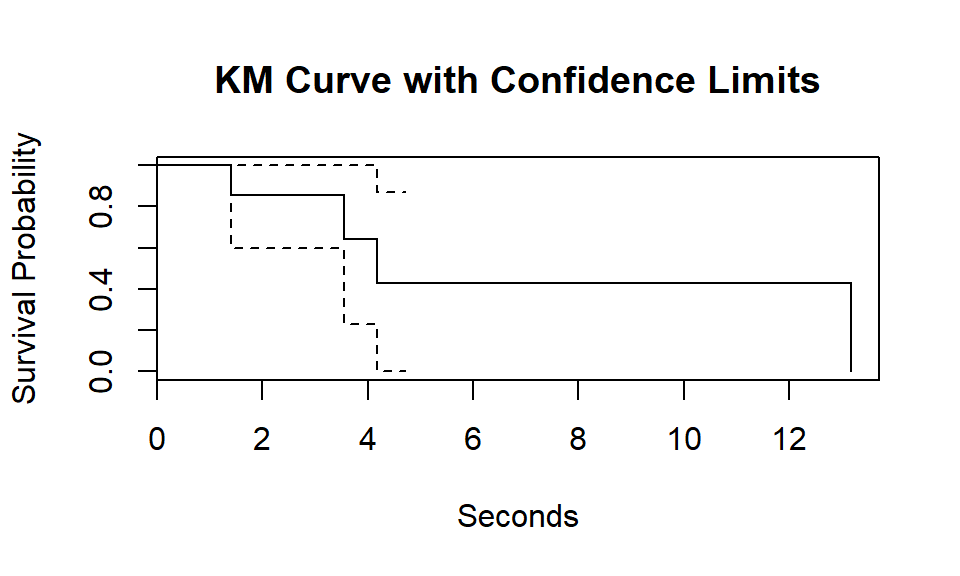

```r
plot(KM_obj,
     xlab = "Seconds",
     ylab = "Survival Probability",
     main = "KM Curve with Confidence Limits")
```

## Nelson-Aelen Estimator of $S(t)$

Use the option `type = "fh"` in the `survfit` function to compute Nelson-Aalen estimates of survival probabilities.

```r
KM_obj_NA <- survfit(Surv(time, censor) ~ 1,
                     data = motorists,
                     type = "fh",
                     conf.type = "none")

summary(KM_obj_NA)
```

```
## Call: survfit(formula = Surv(time, censor) ~ 1, data = motorists, type = "fh",
##     conf.type = "none")
##
##   time n.risk n.event survival std.err
##   1.41      7       1    0.867   0.134
##   3.56      4       1    0.675   0.221
##   4.18      3       1    0.484   0.253
##  13.18      1       1    0.178     Inf
```

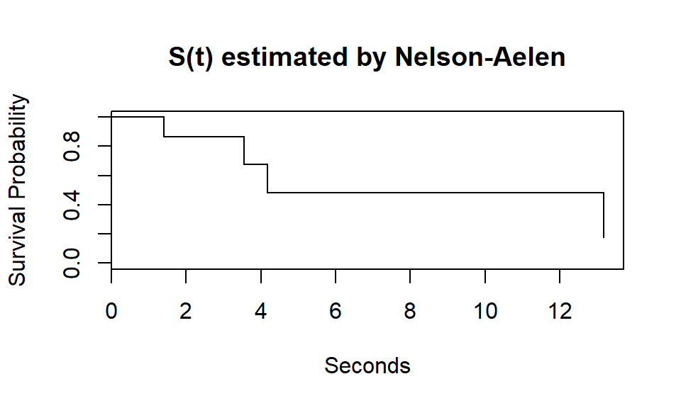

```r
plot(KM_obj_NA,
     xlab = "Seconds",
     ylab = "Survival Probability",
     main = "S(t) estimated by Nelson-Aelen")
```

# Hazard / Cumulative Hazard

## Overview

There are not any built in functions in the `survival` package that plot the estimated hazard rates or cumulative hazards. Two supplemental `R` functions have been written to plot the the Kaplan-Meier estimated hazard function and the Nelson-Aalen cumulative hazard function. The `plot.haz.R` script in the PolyLearn `Data sets` folder contains two functions:

- `plot_haz` plots the Kaplan-Meier estimated hazard function $\hat{h}(t)$
- `plot_chaz` plots the Nelson-Aalen estimated cumulative hazard function $\tilde{H}(t)$

## Accessing the functions

1. Download the R script `plot.haz.R` from PolyLearn and open it in RStudio.
2. With this file open, click on `Source`.
3. Now you should be able to see the two functions `plot_haz` and `plot_chaz` in your `Environment`.
4. To include the source code in an R script or Rmarkdown file:
- Click on `History` in the upper right hand corner of RStudio.
- Scroll down until you see the line of code that begins with `source`. Click on ths line of code. For example:

```r
source("C:/Users/spileggi/Google Drive/STAT 417/plot.haz.R")
```

- Once that line of code is highlighted, click on `To source` and the R code should now appear in your upper left-hand panel. If you are working in an Rmarkdown file (.Rmd), be sure to place this code in a code chunk.

## Plotting

Both functions can be applied to an object created by `survifit`.

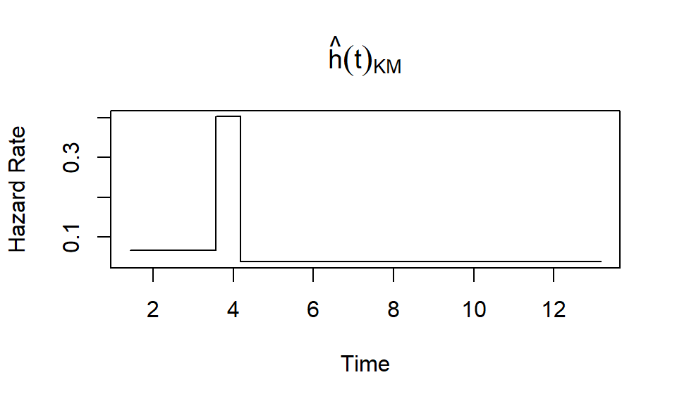

```r
KM_obj <- survfit(Surv(time, censor) ~ 1,
                  data = motorists,
                  conf.type = "none")

plot_haz(KM_obj)
```

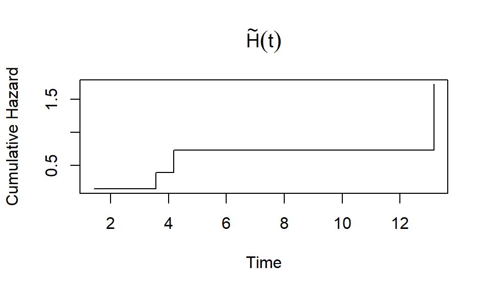

```r
plot_chaz(KM_obj)
```